# Within Participant Correlation – Chile PBMC and Buccal Samples

Philippe Boileau

Since the PBMC and buccal samples were collected from the same participants in the Chile arsenic exposure study, and we are including the EWAS and DVP results of each in a meta-analysis that assumes independent studies, we must verify that the two sample types collected from each patient are uncorrelated. It is Andres and Anne’s *a priori* belief that the tissue-level variation trumps the participant-level variation, such that this assumption of independence is essentially met.

We begin by loading the processed data of each dataset. We then perform a brief exploratory data analysis. Finally, we conclude by evaluating the within-participant tissue similarity.

## Load Data

```r
# buccal samples
load(
  "../../../arsenic-epigenetics-meta/Chile/buccal/data/buccal_funnorm_data.RData"
)
buccal_betas_fun <- betas_fun
buccal_mvals_fun <- mvals_fun
buccal_pheno <- as.data.frame(pheno)
rm(betas_fun, mvals_fun, pheno)

# PBMC samples
load(
  "../../../arsenic-epigenetics-meta/Chile/pbmcs/data/pbmcs_funnorm_data.RData"
)
pbmcs_betas_fun <- betas_fun
pbmcs_mvals_fun <- mvals_fun
pbmcs_pheno <- as.data.frame(pheno)
rm(betas_fun, mvals_fun, pheno)

# exlude the participant who is not paired with any samples in the buccal data
# (recall: one sample failed QC in buccal dataset)
rm_from_pbmcs_idx <- which(!(pbmcs_pheno$study_id %in% buccal_pheno$study_id))
pbmcs_betas_fun <- pbmcs_betas_fun[, -rm_from_pbmcs_idx]
pbmcs_mvals_fun <- pbmcs_mvals_fun[, -rm_from_pbmcs_idx]
pbmcs_pheno <- pbmcs_pheno[-rm_from_pbmcs_idx, ]

# join the values into a single dataframe for EDA purposes
buccal_mvals_fun <- buccal_mvals_fun %>%
  as_tibble(rownames = "CpG")
pbmcs_mvals_fun <- pbmcs_mvals_fun %>%
  as_tibble(rownames = "CpG")
combined_mvals <- buccal_mvals_fun %>%
  inner_join(pbmcs_mvals_fun, by = "CpG")
```

## Exploratory Data Analysis

The top principal components for the top 5000 most variable CpG sites are plotted below. The largest source of variation is attributed to tissue type, as seen in the scree plot and the plots of PC1 vs. PC2 and PC2 vs. PC3. No clear within-participant pattern emerges from the top five PCs.

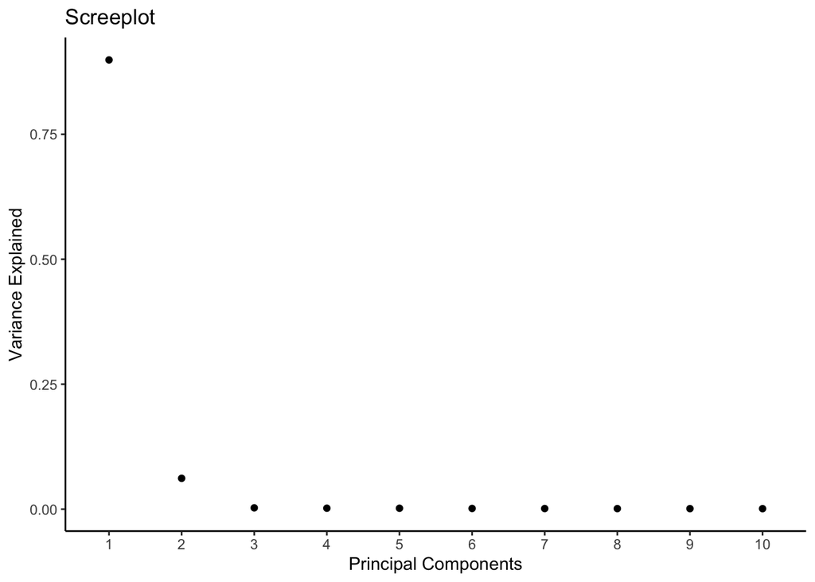

```r
# identify the 1000 most variable CpG sites
top_mvals <- combined_mvals %>%
  select(-CpG) %>%
  as.matrix %>%
  rowVars
combined_mvals$vars <- top_mvals
filtered_combined_mvals <- combined_mvals %>%
  arrange(desc(vars)) %>%
  head(5000)

# perform PCA on these top CpGs
mvals_PCA <- filtered_combined_mvals %>%
  select(-CpG, -vars) %>%
  t %>%
  as.matrix %>%
  prcomp(center = TRUE, scale. = TRUE)

# turn results into a dataframe for easy manipulation
mvals_PCA_df <- mvals_PCA$x[, 1:5] %>%
  as_tibble
mvals_PCA_df$study_id <- c(buccal_pheno$study_id, pbmcs_pheno$study_id)
mvals_PCA_df$tissue <- c(rep("Buccal", 39), rep("PBMC", 39))

# create the scree plot
var_explained <- (mvals_PCA$sdev^2 / sum(mvals_PCA$sdev^2))[1:10]
PCs <- factor(1:10)
screeplot_df <- tibble(var_explained, PCs)
screeplot_df %>%
  ggplot(aes(x = PCs, y = var_explained)) +
    geom_point() +
    xlab("Principal Components") +
    ylab("Variance Explained") +
    ggtitle("Screeplot") +
    theme_classic()
```

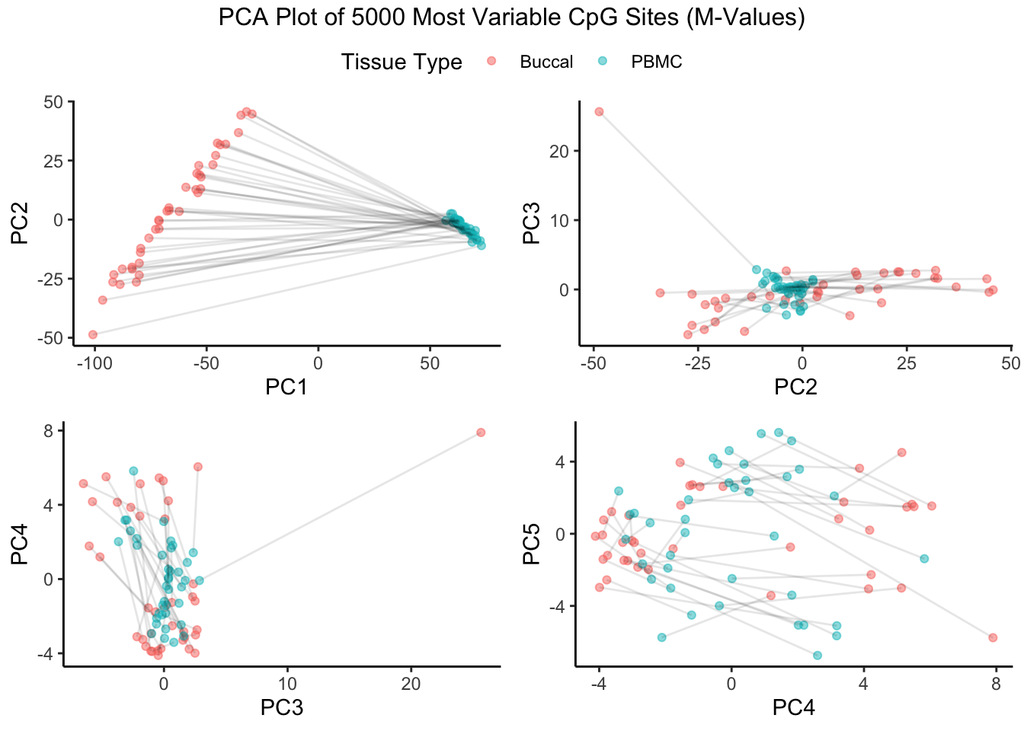

```r
# plot the PCs
PC1_PC2_p <- mvals_PCA_df %>%
  ggplot(aes(x = PC1, y = PC2)) +
    geom_point(aes(colour = tissue), alpha = 0.5) +
    geom_line(aes(group = study_id), alpha = 0.1) +
    scale_colour_discrete(name = "Tissue Type") +
    theme_classic()
PC2_PC3_p <- mvals_PCA_df %>%
  ggplot(aes(x = PC2, y = PC3)) +
    geom_point(aes(colour = tissue), alpha = 0.5) +
    geom_line(aes(group = study_id), alpha = 0.1) +
    scale_colour_discrete(name = "Tissue Type") +
    theme_classic()
PC3_PC4_p <- mvals_PCA_df %>%
  ggplot(aes(x = PC3, y = PC4)) +
    geom_point(aes(colour = tissue), alpha = 0.5) +
    geom_line(aes(group = study_id), alpha = 0.1) +
    scale_colour_discrete(name = "Tissue Type") +
    theme_classic()
PC4_PC5_p <- mvals_PCA_df %>%
  ggplot(aes(x = PC4, y = PC5)) +
    geom_point(aes(colour = tissue), alpha = 0.5) +
    geom_line(aes(group = study_id), alpha = 0.1) +
    scale_colour_discrete(name = "Tissue Type") +
    theme_classic()

ggarrange(
  PC1_PC2_p, PC2_PC3_p, PC3_PC4_p, PC4_PC5_p,
  ncol = 2, nrow = 2, common.legend = TRUE
) %>%
  annotate_figure(top = "PCA Plot of 5000 Most Variable CpG Sites (M-Values)")
```

## Within-Participant Correlations

Here, we compute the Spearman correlations between the tissue samples of each individual over their common CpG sites. This statistic is used only as a measure of similarity – we can’t perform a traditional hypothesis test with these statistics since the random observational units are now being treated as a random variable, and vice-versa.

```r
# order the dataframes based on study id
colnames(buccal_mvals_fun) <- c("CpG", buccal_pheno$study_id)
buccal_mvals_fun <- buccal_mvals_fun[, order(colnames(buccal_mvals_fun))]
colnames(pbmcs_mvals_fun) <- c("CpG", pbmcs_pheno$study_id)
pbmcs_mvals_fun <- pbmcs_mvals_fun[, order(colnames(pbmcs_mvals_fun))]

# retain only common CpG sites
buccal_mvals_fun <- buccal_mvals_fun %>%
  filter(CpG %in% pbmcs_mvals_fun$CpG) %>%
  arrange(CpG)
pbmcs_mvals_fun <- pbmcs_mvals_fun %>%
  filter(CpG %in% buccal_mvals_fun$CpG) %>%
  arrange(CpG) %>%
  select(-CpG)
buccal_mvals_fun <-  buccal_mvals_fun %>%
  select(-CpG)

# compute the observed spearman correlations on all individuals
cor_test_list <- sapply(
  seq_len(ncol(buccal_mvals_fun)),
  function(id) {
    cor.test(pull(buccal_mvals_fun[, id]),
             pull(pbmcs_mvals_fun[, id]),
             method = "spearman")$estimate
  }
)

# compute every possible pair of samples
combo_mat <- t(buccal_mvals_fun %>% colnames %>% combn(2))

# Compute the finite sample distribution of similarities
cor_null_dist <- sapply(
  seq_len(nrow(combo_mat)),
  function(pair) {
    # extract the sample IDs
    pair_1 <- combo_mat[pair, 1]
    pair_2 <- combo_mat[pair, 2]

    # compute pbmc/buccal similarity
    rho_1 <- cor.test(
      pull(buccal_mvals_fun[, which(colnames(buccal_mvals_fun) == pair_1)]),
      pull(pbmcs_mvals_fun[, which(colnames(pbmcs_mvals_fun) == pair_2)]),
      method = "spearman"
    )$estimate

    # compute buccal/pbmc similarity
    rho_2 <- cor.test(
      pull(buccal_mvals_fun[, which(colnames(buccal_mvals_fun) == pair_2)]),
      pull(pbmcs_mvals_fun[, which(colnames(pbmcs_mvals_fun) == pair_1)]),
      method = "spearman"
    )$estimate
    return(c(rho_1, rho_2))
  }
) %>%
  unlist %>%
  ecdf
```

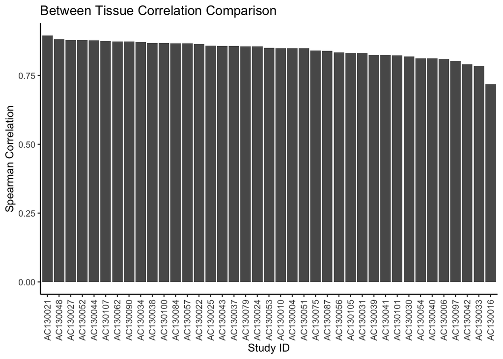

```r
# compute the observed p-values percentiles
p_values <- 1 - cor_null_dist(cor_test_list)
holms_p_values <- p.adjust(p_values, method = "holm")
BH_p_values <- p.adjust(p_values, method = "BH")
results_df <- tibble(
  study_id = colnames(buccal_mvals_fun),
  p_values,
  holms_p_values,
  BH_p_values,
  spearman = cor_test_list
)

# plot the spearman correlations
results_df %>%
  arrange(spearman) %>%
  ggplot(aes(x = reorder(study_id, -spearman), y = spearman)) +
    geom_bar(stat = "identity") +
    xlab("Study ID") +
    ylab("Spearman Correlation") +
    ggtitle("Between Tissue Correlation Comparison") +
    theme_classic() +
    theme(axis.text.x = element_text(angle = 90, vjust = 0.5, hjust = 1))
```

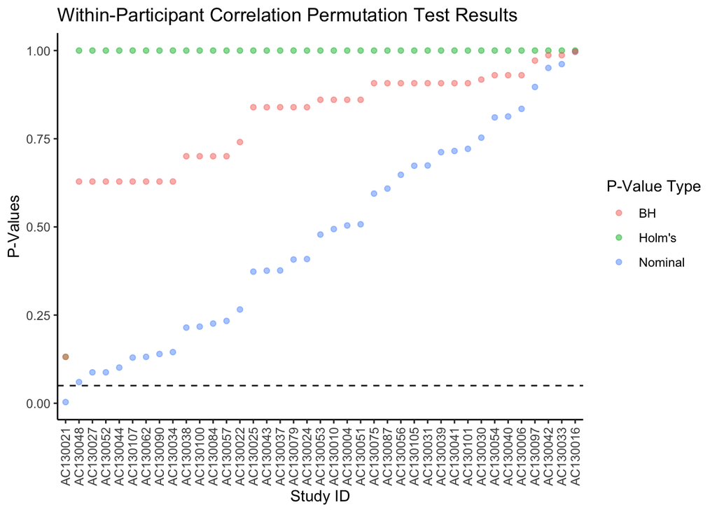

```r
# plot the p-values for each test
results_df %>%
  arrange(spearman) %>%
  pivot_longer(cols = ends_with("_values"),
               names_to = "type", values_to = "value") %>%
  mutate(
    type = if_else(type == "BH_p_values", "BH",
             if_else(type == "holms_p_values", "Holm's", "Nominal"))
  ) %>%
  ggplot(aes(x = reorder(study_id, -spearman), y = value, colour = type)) +
    geom_point(alpha = 0.5) +
    geom_hline(yintercept = 0.05, colour = "black", linetype = 2) +
    xlab("Study ID") +
    ylab("P-Values") +
    ggtitle("Within-Participant Correlation Permutation Test Results") +
    scale_colour_discrete(name = "P-Value Type") +
    theme_classic() +
    theme(axis.text.x = element_text(angle = 90, vjust = 0.5, hjust = 1))
```